# Mapping the Arctic

*Robert Schlegel*

## Problem

- How do we plot maps near the poles more accurately?
- What effect does this have on other map layers?
- This is time intensive, is there a faster way?

## Solution

- We must learn more about map projections
- We will look at packages that help us project raster layers etc.
- **`ggoceanmaps`** provides the full suite of solutions

## Setup

```r
# Load libraries
library(tidyverse)

# Load data
```

## The Earth is round

No matter what you’ve heard, its not flat. Proof of this is that if it were flat, it would be much easier to plot parts of it on a map! Instead, because the surface of the Earth is curved, we cannot accurately plot it on a computer screen.

The way we deal with this is by changing the measurements between longitude/latitude coordinates. The technical word is ‘projecting’. The noun is ‘projection’ or ‘projections’.

For much of the Earth this is not that noticeable. But for the Arctic it is a big issue.

## Map projections

There are many different sorts of map projections in use. Over tea time I recommend googling them. There are some funny ones.

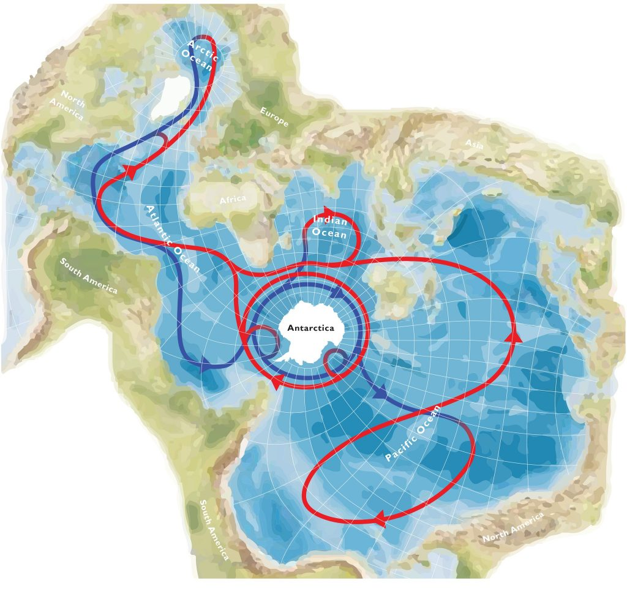

The Spilhaus projection is oriented around the global ocean.

## Map projections

R has many built-in projections, and **`ggplot2`** gives us easy access to many of them.

```r
# Type the following in your console,
# see what comes up as auto-complete suggestions
# Use the up and down arrows to scroll through
coord_
```

## Cartesian projections

- This is the default coordinate projection
- Basically, it doesn’t alter the lon/lat decimal degree coordinates in any way

```r
ggplot() +
  borders(fill = "grey70", colour = "black") + # The global shape file
  coord_cartesian() # Numeric sizing for lon/lat
```

[output not shown]

## Equal projections

- This projects numeric x/y (e.g. lon/lat) values the same

```r
ggplot() +
  borders(fill = "grey70", colour = "black") + # The global shape file
  coord_equal() # Equal sizing for lon/lat
```

[output not shown]

## Fixed projections

```r
ggplot() +
  borders(fill = "grey70", colour = "black") + # The global shape file
  coord_fixed(ratio = 2) # Ratio (Y divided by X) sizing for lon/lat
```

[output not shown]

## Map projections

```r
ggplot() +
  borders(fill = "grey70", colour = "black") + # The global shape file
  coord_sf() # sf = simple feature
```

[output not shown]

## Polar projections

```r
ggplot() +
  borders(fill = "grey70", colour = "black") + # The global shape file
  coord_polar() # Equal sizing for lon/lat
```

[output not shown]